# Linear mixed-effects models

## Regression models

- Often introduced as fitting lines to points.
- Limited perspective that makes more complex regression models, like generalised linear models, hard to understand.
- Extension to generalised and multilevel linear models (multiple / simple linear regressions, AN(C)OVAs, MAN(C)OVAs)
- Backbone of statistical modelling: machine learning, time series models, path analysis, structural equation models, factor analysis, signal detection models

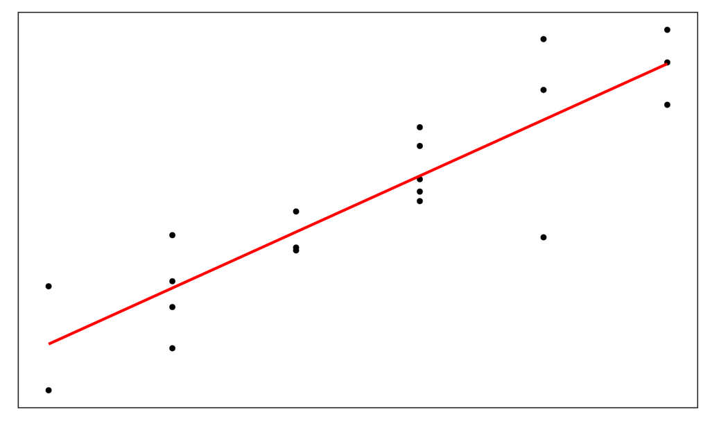

## Regression models

- A model of how the probability distribution of one variable, known as the *outcome variable*, varies as a function of other variables, known as the *explanatory* or *predictor variables*.
- The most basic type of regression models is the normal linear model.
- In normal linear models, we assume that the outcome variable is normally distributed and that its mean varies linearly with changes in a set of predictor variables.
- By understanding the normal linear model thoroughly, we can see how it can be extended to deal with data and problems beyond those that it is designed for.

## Normal linear model (formal description)

\[ \begin{aligned} y_i &\sim \mathcal{N}(\mu, \sigma^2) \end{aligned} \]

- \(y\): observed *outcome* variable
- Each observation \(y_i\) is a sample (indexed by \(i\))
- Lower case letters indicate observed variables.
- “\(\sim\)”: “is proportional to” / “is a function of”
- \(\mathcal{N}\): univariate normal distributed probability model; i.e. the underlying process that describes the nature of our data.
- **Population parameters** are represented as Greek letters; i.e. mean \(\mu\) and variance \(\sigma^2\) (parameters depend on probability model and parametrisation).

## Normal linear model (formal description)

\[ \begin{aligned} y_i &\sim \mathcal{N}(\mu_i, \sigma^2)\\ \mu_i &= \beta_0 + \beta_1 \cdot x_{1i} \\ \end{aligned} \]

Value of \(\mu_i\) can be decomposed using a linear regression equation.

- \(\beta_1\) directly depends on explanatory variable \(x_{1i}\)
- \(\beta_0\) is “constant”
- If \(x_{1i}\) takes on 0, \(\mu_i = \beta_0\)
- If \(x_{1i}\) takes on 1, \(\mu_i = \beta_0 + \beta_1\)
- \(\beta_1\) is the difference between \(x_{1i}=1\) and \(x_{1i}=0\).
- Value of \(\mu_i\) is deterministic (“\(=\)”) linear function of values of one or more predictor variables \(x\) and the unknowns \(\beta_0\) (intercept) and \(\beta_1\) (slope).

## Simulation of normal distributed data

- We can use `lm` to easily implement such a model.

```r
model <- lm(y ~ x, data = data)
```

- We can simulate data that exactly meet model assumptions (normal distribution, equal variance, independence etc.) with known model parameters.

## Simulation of normal distributed data

- `rnorm` generates unimodal, symmetrically distributed values.
- `r` in `rnorm` = random; `norm` = normal

```r
# Generate data
y <- rnorm(n = 10, mean = 550, sd = 10)
```

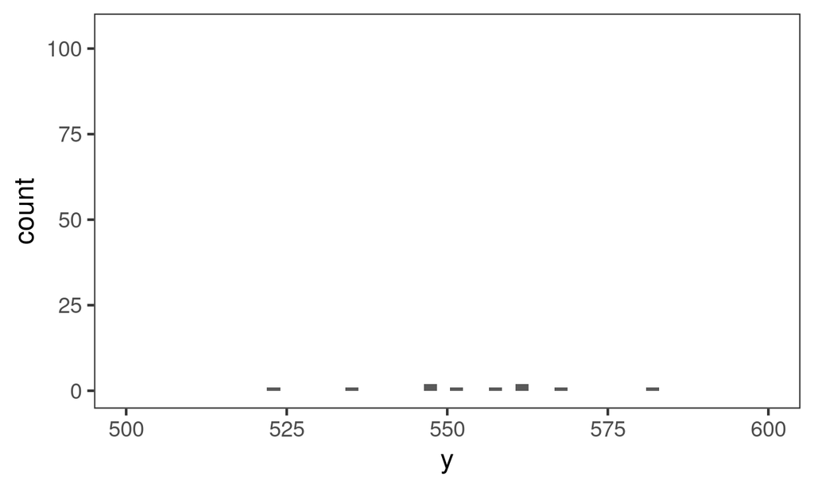

## Simulation of normal distributed data

- `rnorm` generates unimodal, symmetrically distributed values.
- `r` in `rnorm` = random; `norm` = normal

```r
# Generate data
y <- rnorm(n = 100, mean = 550, sd = 10)
```

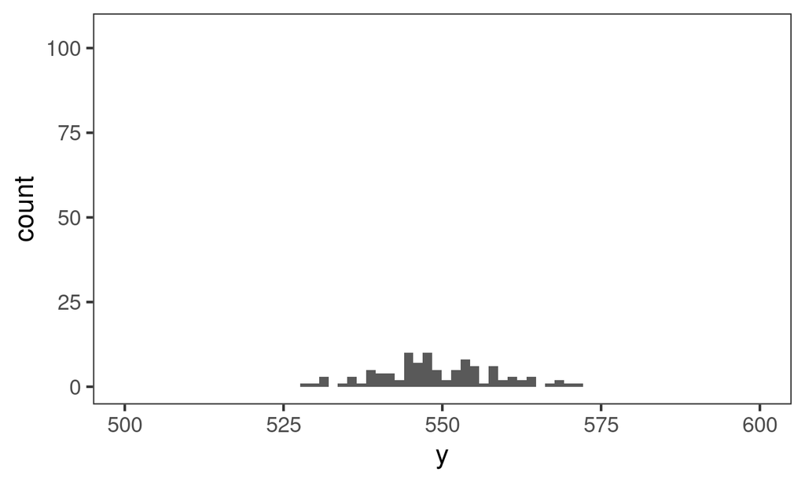

## Simulation of normal distributed data

- `rnorm` generates unimodal, symmetrically distributed values.
- `r` in `rnorm` = random; `norm` = normal

```r
# Generate data
y <- rnorm(n = 1000, mean = 550, sd = 10)
```

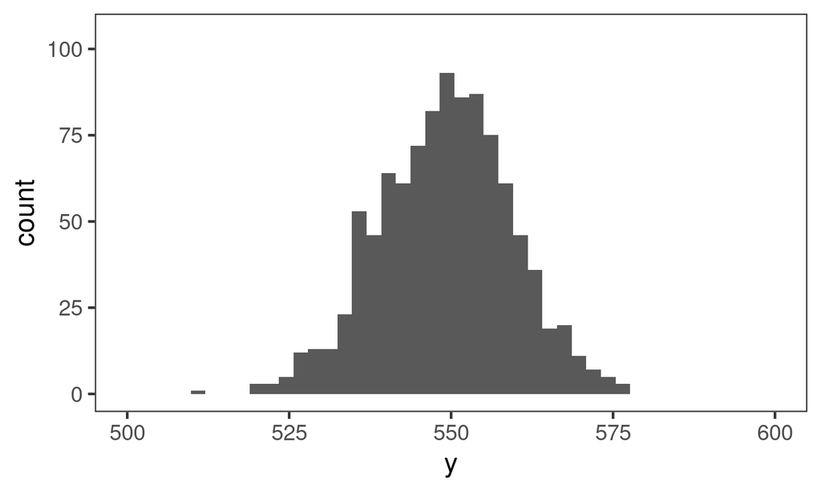

## Simulation of normal distributed data

- `rnorm` generates unimodal, symmetrically distributed values.
- `r` in `rnorm` = random; `norm` = normal

```r
# Decompose the mean
beta_0 = 500
beta_1 = 50
# Generate data
y <- rnorm(n = 1000, mean = beta_0 + beta_1, sd = 10)
```

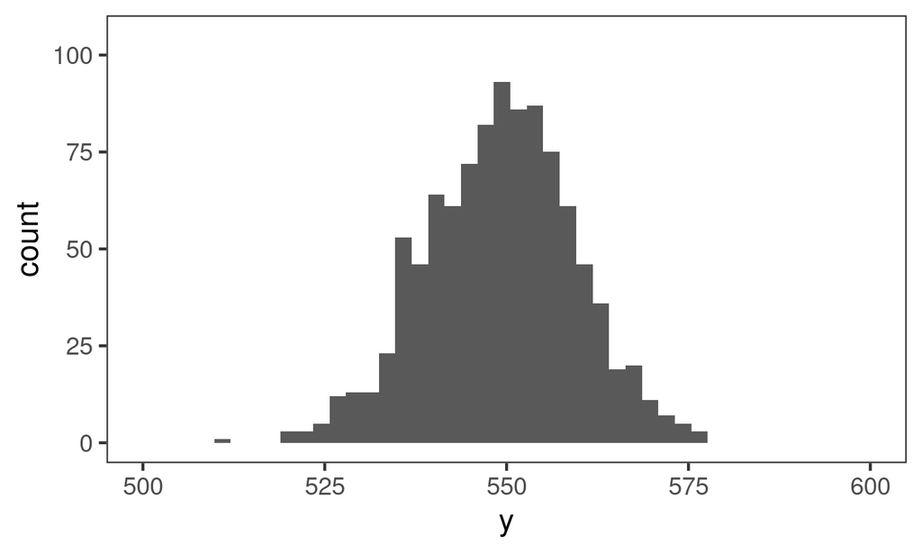

## Simulation of normal distributed data

```r
# Set parameter values
n <- 1000
beta_0 <- 500
beta_1 <- 50
sigma <- 100
```

```r
# Random data for group 1
group_1 <- rnorm(n = n/2, mean = beta_0, sd = sigma)
# Random data for group 2
group_2 <- rnorm(n = n/2, mean = beta_0 + beta_1, sd = sigma)
```

```r
# Generate data
sim_data <- tibble(group_1 = group_1,
                   group_2 = group_2)

# Preview data
glimpse(sim_data)
```

```
Rows: 500
Columns: 2
$ group_1 <dbl> 176, 436, 465, 465, 660, 673, 530, 460, 672, 556, 449, 370, 53…
$ group_2 <dbl> 417, 524, 618, 489, 704, 612, 608, 565, 439, 667, 664, 644, 45…
```

```r
# Change data format
sim_data <- pivot_longer(sim_data, cols = c(group_1, group_2), names_to = "x", values_to = "y")

# Preview data
glimpse(sim_data)
```

```
Rows: 1,000
Columns: 2
$ x <chr> "group_1", "group_2", "group_1", "group_2", "group_1", "group_2", "g…
$ y <dbl> 176, 417, 436, 524, 465, 618, 465, 489, 660, 704, 673, 612, 530, 608…
```

## Simulation of normal distributed data

```r
# As a reminder, these are the parameter values
beta_0 <- 500
beta_1 <- 50
sigma <- 100
```

```r
# Normal linear model of simulated data
model <- lm(y ~ x, data = sim_data)

coef(model) # Model coefficients
```

```
(Intercept)    xgroup_2
      504.0        45.8
```

```r
sigma(model) # Standard deviation
```

```
[1] 96.6
```

## Simulation: exercise

Check scripts

- `exercises/normal_model_simulation_1.R`
- `exercises/normal_model_simulation_2.R`

You will need to complete the code in those scripts. Observe how changing the number of observations affects the model estimates.

## Real data

- In real life we don’t know the true parameter values.
- We also don’t know the true process that generates the data.
- For the simulated data we know that the process:
  - a normal distribution because `rnorm` samples normally distributed data
  - both groups have the same (equal) variance because the value for `sigma` was the same.
- We can use linear models to estimate parameter values from the data (i.e. we make assumptions about the process that generates the data).
- Maximum likelihood estimation: for which set of parameter values are the data most likely.

## Martin et al. (2010) data (Experiment 3a)

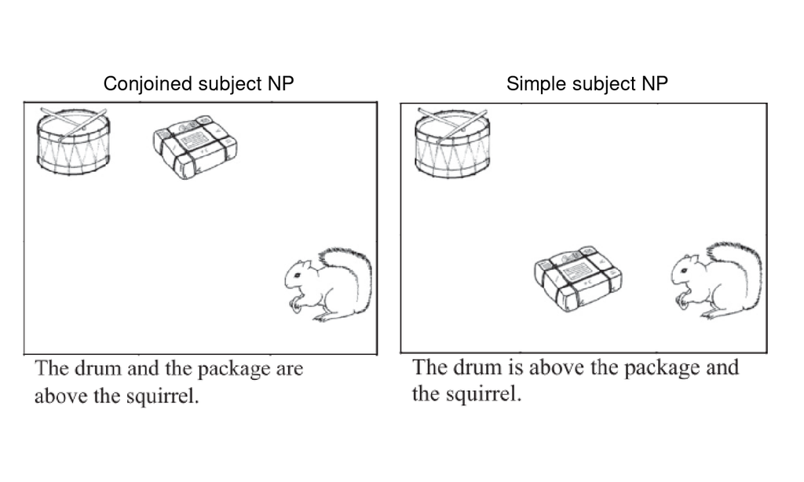

```r
p1 <- image_read("../gfx/Martin2014stim_conjoined.png") %>% image_ggplot() +
  labs(title = "Conjoined subject NP") +
  theme(plot.title = element_text(hjust = 0.5))
p2 <- image_read("../gfx/Martin2014stim_simple.png") %>% image_ggplot() +
  labs(title = "Simple subject NP") +
    theme(plot.title = element_text(hjust = 0.5))

p1 + p2
```

```r
data <- read_csv("../data/martin-etal-2010-exp3a.csv") %>% glimpse()
```

```
Rows: 1,036
Columns: 4
$ item   <dbl> 11, 11, 11, 11, 11, 11, 25, 25, 25, 25, 25, 37, 37, 37, 37, 5, …
$ ppt    <dbl> 10, 9, 11, 6, 7, 2, 10, 9, 11, 7, 2, 10, 9, 6, 2, 10, 9, 11, 6,…
$ rt     <dbl> 1055, 2010, 461, 977, 1152, 1079, 1194, 1267, 1160, 684, 1367, …
$ nptype <chr> "conjoined", "conjoined", "conjoined", "conjoined", "conjoined"…
```

```r
summarise(data, across(c(ppt, item), list(n = ~length(unique(.))), .names = "{col}"))
```

```
# A tibble: 1 × 2
    ppt  item
  <int> <int>
1    12    48
```

## Aggregation by participants (across items)

In standard repeated measures ANOVAs only one source of variance can be modelled at a time.

For example one would aggregate across items and by-participant neglecting the by-items variance.

```r
data_ppt <- data %>% summarise(rt = mean(rt), .by = c(nptype, ppt))
data_ppt
```

```
# A tibble: 24 × 3
  nptype      ppt    rt
  <chr>     <dbl> <dbl>
1 conjoined    10  944.
2 conjoined     9 1298.
3 conjoined    11 1410.
4 conjoined     6 1000.
5 conjoined     7  922.
# ℹ 19 more rows
```

## Participant variation (by-participant means)

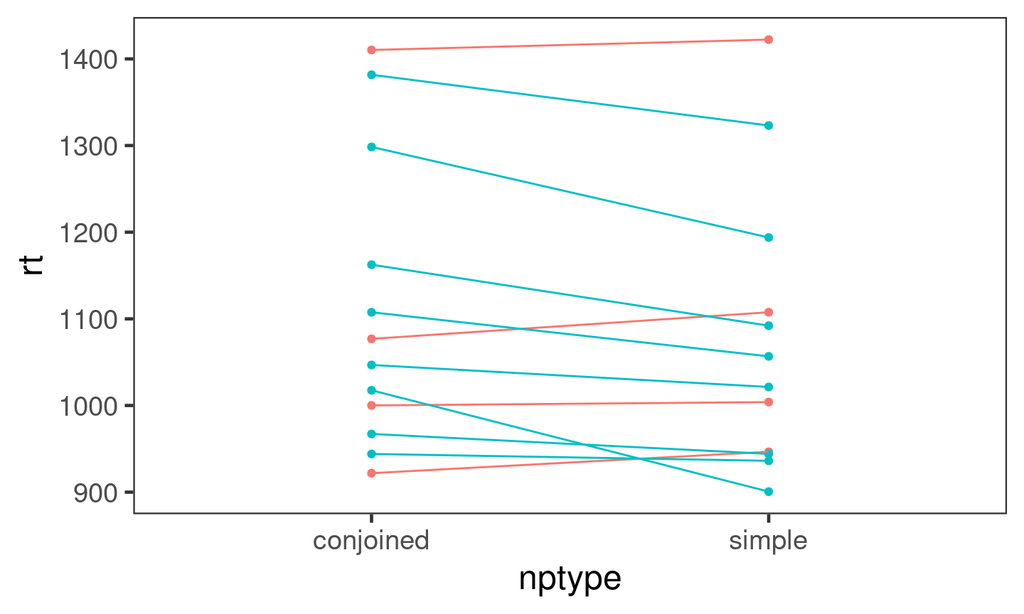

## Model description

Each rt observation \(i \in 1 \dots N\) can be said to come a normal distribution with a mean \(\mu\) and a standard deviation \(\sigma^2\)

\[ \text{rt}_i \sim \mathcal{N}(\mu_i, \sigma^2)\\ \]

Using the linear regression equation, the mean \(\mu\) can be decomposed into

where \(\text{nptype}_i\) is dummy coded (by default as treatment contrast in alphabetical order)

and

\(\text{ppt}_i \sim \mathcal{N}(0, \sigma^2_\text{ppt})\)

## Model implementation in R

```r
library(afex)
m <- aov_car(rt ~ Error(ppt/nptype), data = data_ppt)
summary(m)
```

```
Univariate Type III Repeated-Measures ANOVA Assuming Sphericity

              Sum Sq num Df Error SS den Df F value  Pr(>F)
(Intercept) 28783750      1   587304     11  539.11 1.1e-10 ***
nptype          6217      1    13043     11    5.24   0.043 *
---
Signif. codes:  0 '***' 0.001 '**' 0.01 '*' 0.05 '.' 0.1 ' ' 1
```

```r
library(lme4)
m <- lmer(rt ~ nptype + (1|ppt), data = data_ppt)
anova(m)
```

```
Type III Analysis of Variance Table with Satterthwaite's method
       Sum Sq Mean Sq NumDF DenDF F value Pr(>F)
nptype   6217    6217     1    11    5.24  0.043 *
---
Signif. codes:  0 '***' 0.001 '**' 0.01 '*' 0.05 '.' 0.1 ' ' 1
```

## Real data

> Predictor variable sex is denoted as \(\text{sex}_1, \text{sex}_2, \dots \text{sex}_n\), \(\text{ for } i \in 1\dots n\)

\[ \text{logrt}_i \sim \mathcal{N}(\mu_i, \sigma^2)\\ \mu_i = \beta_0 + \beta_\text{sex} \cdot \text{sex}_i \]

> where \(\text{sex}_i\) takes on \(0\) for females and \(1\) for males.

\[ \text{sex}_i = \left\{ \begin{array}{ll} 0, \text{ if sex}_i = \texttt{female}\\ 1, \text{ if sex}_i = \texttt{male}\\ \end{array} \right. \]

## Exercise on repeated measures ANOVA

Complete exercise script `linear-models/exercises/repeated_measures_model.R`

and after that `linear-models/exercises/mixed_effects_model.R`

## Item variation (by-image sets means)

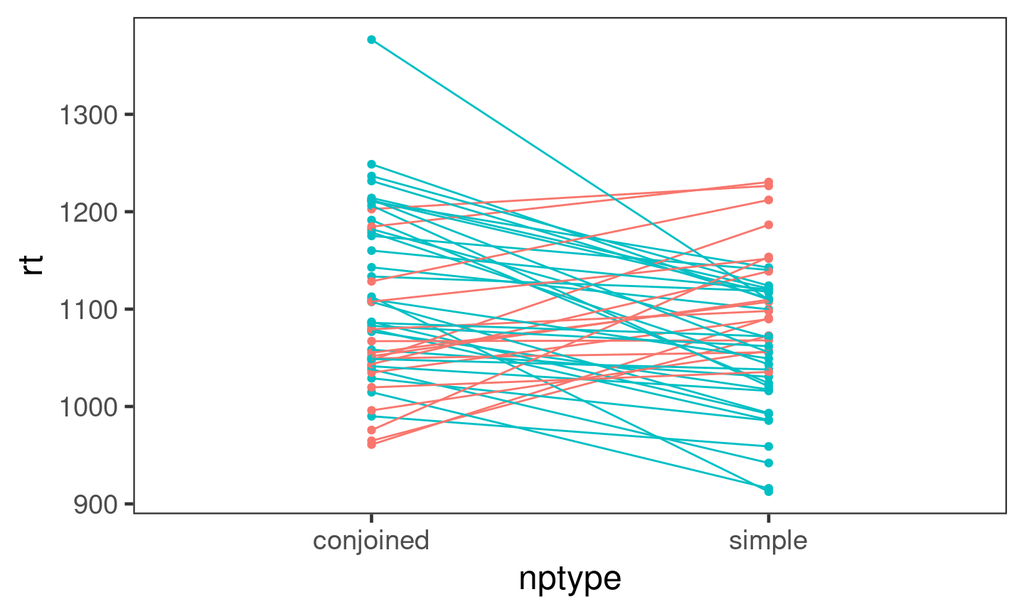

## What’s a mixed effects model?

- Models with a combination of fixed (intercepts and slopes) and random effects.
- Repeated measures ANOVA are a special type of mixed-effects models.
- Linear models is not as contrained as ANOVAs.
- Fixed effects: systematic / deterministic effects (e.g. age, trial id, grouping variables)
- Random effects: non-systematic effects (e.g. ppts, items, class, country)
- Random effects can be nested: people within country
- Sometimes the differences can be blurry: comparing differences between two test sites rather than treating test sites as repeated measures variable.

## Crossed random intercepts for participants and items (Baayen, Davidson, and Bates 2008)

- Repeated-measures ANOVA can only handle either participant or item variance
- Linear mixed-effects models can capture both.

```r
m <- lmer(rt ~ nptype + (1|ppt) + (1|item), data = data)
```

```r
summary(m)$coef
```

```
             Estimate Std. Error    df t value Pr(>|t|)
(Intercept)    1111.8       48.0  11.9    23.2 3.11e-11
nptypesimple    -33.4       14.5 977.9    -2.3 2.16e-02
```

## How to get null-hypothesis for `lmer` models?

- Likelihood ratio test

```r
m_null <- lmer(rt ~ 1 + ( 1 | ppt ) + ( 1 | item ), data = data)
anova(m_null, m)
```

```
Data: data
Models:
m_null: rt ~ 1 + (1 | ppt) + (1 | item)
m: rt ~ nptype + (1 | ppt) + (1 | item)
       npar   AIC   BIC logLik deviance Chisq Df Pr(>Chisq)
m_null    4 14319 14339  -7155    14311
m         5 14316 14340  -7153    14306  5.28  1      0.022 *
---
Signif. codes:  0 '***' 0.001 '**' 0.01 '*' 0.05 '.' 0.1 ' ' 1
```

- Satterthwaite approximation for degrees of freedom (`lmerTest`)

```r
m <- lmerTest::lmer(rt ~ nptype + (1|ppt) + (1|item), data = data)
summary(m)$coef
```

```
             Estimate Std. Error    df t value Pr(>|t|)
(Intercept)    1111.8       48.0  11.9    23.2 3.11e-11
nptypesimple    -33.4       14.5 977.9    -2.3 2.16e-02
```

- *t*-values larger than |2| roughly correspond to a significance level of \(\alpha = .05\) (Baayen 2008)
- Confidence intervals: 95% CI shows the range of hypotheses that can be ruled out for \(\alpha = .05\)

```r
confint(m, "nptypesimple")
```

```
             2.5 % 97.5 %
nptypesimple -61.8  -4.93
```

- But who needs *p*-values anyway :)

## Crossed random intercepts for participants and items

```r
summary(m)
```

```
Linear mixed model fit by REML. t-tests use Satterthwaite's method [
lmerModLmerTest]
Formula: rt ~ nptype + (1 | ppt) + (1 | item)
   Data: data

REML criterion at convergence: 14289

Scaled residuals:
   Min     1Q Median     3Q    Max
-4.518 -0.596 -0.140  0.448  4.965

Random effects:
 Groups   Name        Variance Std.Dev.
 item     (Intercept)  1649     40.6
 ppt      (Intercept) 25996    161.2
 Residual             54536    233.5
Number of obs: 1036, groups:  item, 48; ppt, 12

Fixed effects:
             Estimate Std. Error     df t value Pr(>|t|)
(Intercept)    1111.8       48.0   11.9    23.1  3.1e-11 ***
nptypesimple    -33.4       14.5  977.9    -2.3    0.022 *
---
Signif. codes:  0 '***' 0.001 '**' 0.01 '*' 0.05 '.' 0.1 ' ' 1

Correlation of Fixed Effects:
            (Intr)
nptypesimpl -0.151
```

## Random intercepts (variances)

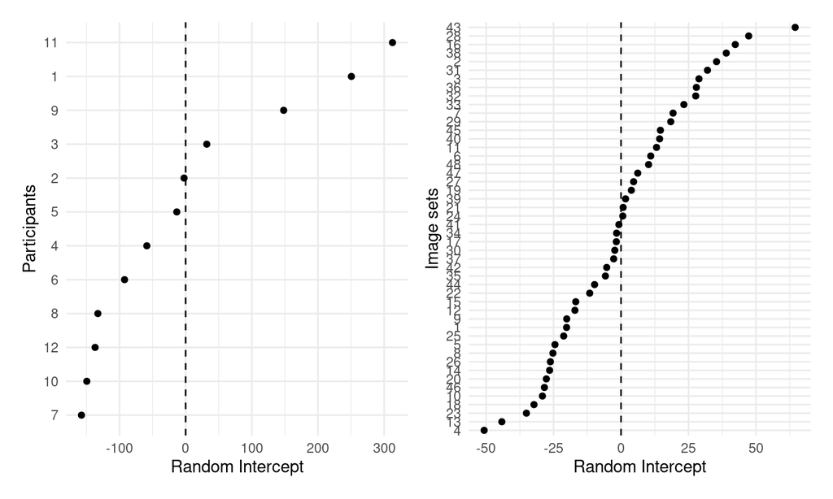

## Random intercepts (variances)

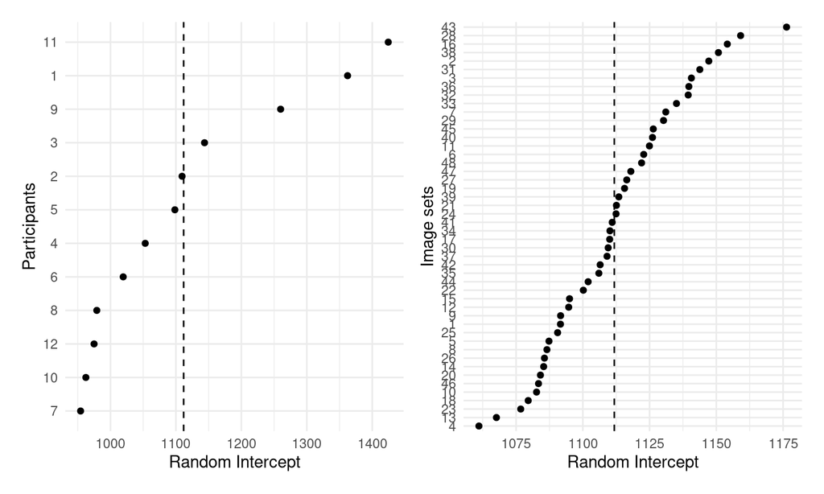

## Predicted out comes

```r
summary(m)$coef
```

```
             Estimate Std. Error    df t value Pr(>|t|)
(Intercept)    1111.8       48.0  11.9    23.2 3.11e-11
nptypesimple    -33.4       14.5 977.9    -2.3 2.16e-02
```

```r
(coefs <- m@beta) # extract estimates
```

```
[1] 1111.8  -33.4
```

```r
# Predicted mean for np conjoined
coefs[1] + coefs[2] * 0
```

```
[1] 1112
```

```r
# Predicted mean for np simple
coefs[1] + coefs[2] * 1
```

```
[1] 1078
```

```r
# Check predictor contrasts (default: treatment)
contrasts(factor(data$nptype))
```

```
          simple
conjoined      0
simple         1
```

## What does the model predict for participants and item?

```r
data_pred <- expand.grid(item = 1:48, ppt = 1:12, nptype = unique(data$nptype)) %>%
  mutate(pred = predict(m, newdata = .),
         m = "random intercepts")
```

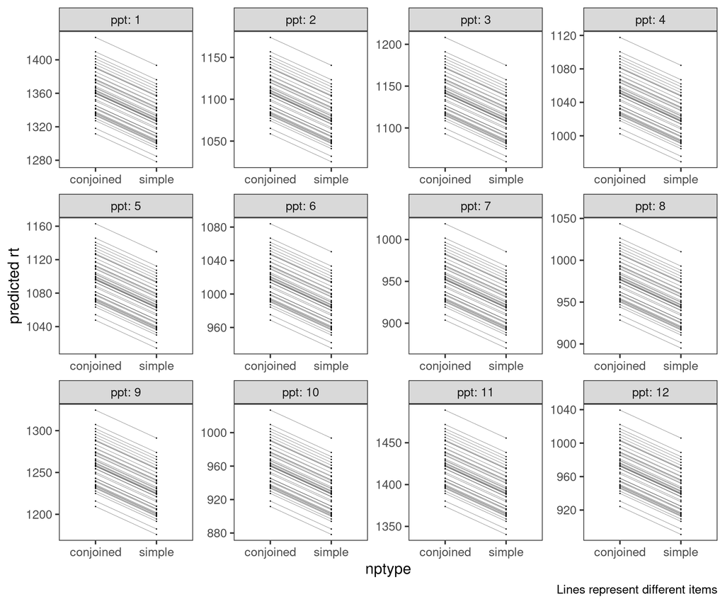

## Random intercepts and random slopes models

- Random slopes: NP-type effect is differently strong for certain participants and items.
- Correlation between random intercepts and slopes: E.g. NP-type effect might be weaker for participants / items with longer rts.
- Maximal random effects structure (Barr et al. 2013): for repeated measures within participants design we need random intercepts for participants and items with by-participants and by-items random slopes for NP type.

```r
select(data, item, nptype) %>% unique() %>% arrange(item, nptype)
```

```
# A tibble: 96 × 2
   item nptype
  <dbl> <chr>
1     1 conjoined
2     1 simple
3     2 conjoined
4     2 simple
5     3 conjoined
# ℹ 91 more rows
```

```r
select(data, ppt, nptype) %>% unique() %>% arrange(ppt, nptype)
```

```
# A tibble: 24 × 2
    ppt nptype
  <dbl> <chr>
1     1 conjoined
2     1 simple
3     2 conjoined
4     2 simple
5     3 conjoined
# ℹ 19 more rows
```

## Random intercepts and random slopes models

```r
# Maximal random effects structure (with correlation)
m_max <- lmer(rt ~ nptype + (nptype|ppt) + (nptype|item), data = data)

# Maximal random effects structure (without correlation)
m_max_nocor <- lmer(rt ~ nptype + (nptype||ppt) + (nptype||item), data = data)
```

## Random intercepts and random slopes models

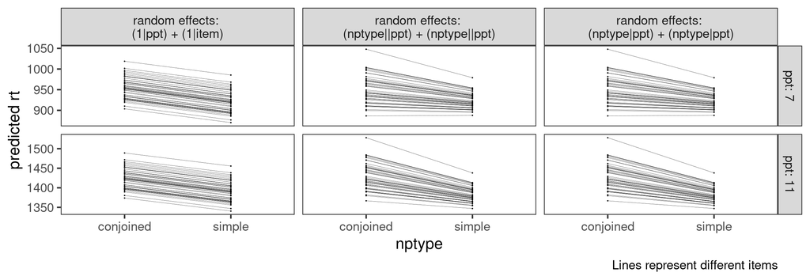

```r
bind_rows(data_pred, data_pred_cor, data_pred_nocor) %>%
  filter(ppt %in% c(7, 11)) %>%
  mutate(across(m, ~case_when(str_detect(., "intercepts") ~ "\n(1|ppt) + (1|item)",
                              str_detect(., "without") ~ "\n(nptype||ppt) + (nptype||ppt)",
                              str_detect(., "with ") ~ "\n(nptype|ppt) + (nptype|ppt)"))) %>%
  rename(`random effects` = m) %>%
  ggplot(aes(x = nptype, y = pred, group = item)) +
  geom_point(size = .1) +
  geom_line(linewidth = .1) +
  facet_grid(ppt ~ `random effects`, scales = "free", labeller = label_both) +
  labs(y = "predicted rt", caption = "Lines represent different items")
```

## Model coefficients of maximal random-effects model

```r
# Maximal random effects structure (with correlation)
m_max <- lmer(rt ~ nptype + (nptype|ppt) + (nptype|item), data = data)
summary(m_max)
```

```
Linear mixed model fit by REML. t-tests use Satterthwaite's method [
lmerModLmerTest]
Formula: rt ~ nptype + (nptype | ppt) + (nptype | item)
   Data: data

REML criterion at convergence: 14288

Scaled residuals:
   Min     1Q Median     3Q    Max
-4.505 -0.596 -0.147  0.449  5.002

Random effects:
 Groups   Name         Variance Std.Dev. Corr
 item     (Intercept)   2749.8   52.44
          nptypesimple   522.1   22.85   -1.00
 ppt      (Intercept)  27159.7  164.80
          nptypesimple    52.4    7.24   -1.00
 Residual              54359.2  233.15
Number of obs: 1036, groups:  item, 48; ppt, 12

Fixed effects:
             Estimate Std. Error     df t value Pr(>|t|)
(Intercept)    1111.9       49.3   11.5   22.58    7e-11 ***
nptypesimple    -33.6       15.0  125.7   -2.24    0.027 *
---
Signif. codes:  0 '***' 0.001 '**' 0.01 '*' 0.05 '.' 0.1 ' ' 1

Correlation of Fixed Effects:
            (Intr)
nptypesimpl -0.310
optimizer (nloptwrap) convergence code: 0 (OK)
boundary (singular) fit: see help('isSingular')
```

## Hypothetical examples for maximal random effects structure

Task: pair designs with their corresponding maximal random-effects structure!

- Design 1 (between participants / within items): both NP type conditions were presented for each item set but half of the participants saw simple NPs and the other half saw conjoined NPs.
- Design 2 (within participants / within items): each participant saw both conditions and each item was presented in both conditions.
- Design 3 (within participants / between items): half of all items were conjoined and the other half were simple NP type; each participant saw both condition (simple NPs and conjoined NPs).
- Design 4 (between participants / between items): half of all items were conjoined and half were simple NP type; half of the participants saw simple NPs and the other half saw conjoined NPs.

```r
Model_A <- lmer(rt ~ nptype + (1|ppt) + (nptype|item), data = data)
Model_B <- lmer(rt ~ nptype + (1|ppt) + (1|item), data = data)
Model_C <- lmer(rt ~ nptype + (nptype|ppt) + (nptype|item), data = data)
Model_D <- lmer(rt ~ nptype + (nptype|ppt) + (1|item), data = data)
```

## Exercise

Complete exercise script `linear-models/exercises/mixed_effects_model_rirs.R`

## Generalised linear models

Type of outcome variable

- Continuous: `lme4::lmer(dv ~ iv + (random slopes | random intercepts), data = data)`
- Binary: `lme4::glmer(dv ~ iv + (random slopes | random intercepts), data = data, family = binomial())`
- Count: `lme4::glmer(dv ~ iv + (random slopes | random intercepts), data = data, family = poisson())`
  - Also negative-binomial `lme4::glmer.nb` and zero-inflated count models `NBZIMM::glmm.zinb`
- Ordinal: `ordinal::clmm(dv ~ iv + (random slopes | random intercepts), data = data)`

Frequentist mixed-effects models require familiarity with different packages.

## Generalised linear models

Top tip:

- Convergence failures (and other problems like floor and ceiling effects) can be (easily) addressed in Bayesian models.
- There is no other R package that allows a straightforward implementation of as many probability models as `brms` (Bürkner 2017) using a syntax that roughly mimics `lme4`
- More flexibility is on possible when using Stan directly (Annis, Miller, and Palmeri 2017; Carpenter et al. 2017).

## Next bits

- intro to bayes
- intro to brms
- apply brms and compare to lme4
- posterior estimate and PIs
- priors and refit model with weakly informative priors
- hypothesis testing using probability mass, ROPE, and BF
- other probability models
- model comparisons and cross-validation

## Recommended reading

## References

Annis, Jeffrey, Brent J Miller, and Thomas J Palmeri. 2017. “Bayesian Inference with Stan: A Tutorial on Adding Custom Distributions.” *Behavior Research Methods* 49: 863–86.

Baayen, R. Harald. 2008. *Analyzing Linguistic Data. A Practical Introduction to Statistics Using R*. Cambridge: Cambridge University Press.

Baayen, R. Harald, Douglas J. Davidson, and Douglas M. Bates. 2008. “Mixed-Effects Modeling with Crossed Random Effects for Subjects and Items.” *Journal of Memory and Language* 59 (4): 390–412.

Barr, Dale J, Roger Levy, Christoph Scheepers, and Harry J Tily. 2013. “Random Effects Structure for Confirmatory Hypothesis Testing: Keep It Maximal.” *Journal of Memory and Language* 68 (3): 255–78.

Bates, Douglas, Reinhold Kliegl, Shravan Vasishth, and Harald Baayen. 2015. “Parsimonious Mixed Models.” *arXiv Preprint arXiv:1506.04967*.

Bürkner, Paul-Christian. 2017. “Brms: An R Package for Bayesian Multilevel Models Using Stan.” *Journal of Statistical Software* 80: 1–28.

Carpenter, Bob, Andrew Gelman, Matthew D Hoffman, Daniel Lee, Ben Goodrich, Michael Betancourt, Marcus Brubaker, Jiqiang Guo, Peter Li, and Allen Riddell. 2017. “Stan: A Probabilistic Programming Language.” *Journal of Statistical Software* 76: 1–32.

Eager, Christopher D, and Joseph Roy. 2017. “Mixed Models Are Sometimes Terrible.” *Linguistic Society of America, Austin, TX*.

Kimball, A, Kailen Shantz, C Eager, and Joseph Roy. 2016. “Beyond Maximal Random Effects for Logistic Regression: Moving Past Convergence Problems.” *ArXiv e-Prints*.

Martin, Randi C, Jason E Crowther, Meredith Knight, Franklin P Tamborello II, and Chin-Lung Yang. 2010. “Planning in Sentence Production: Evidence for the Phrase as a Default Planning Scope.” *Cognition* 116 (2): 177–92.